# MED264: Statistics for Biomedical Informaticss

Jihoon Kim (j5kim@ucsd.edu)

11/7/2017

### Topics covered

Complements MATH283 Statistical Methods in Bioinformatics (Glenn Tesler; http://www.math.ucsd.edu/~gptesler/283/calendar.html)

- Permutation test
- Sample size/statistical power
- Interrater agreement
- Logistic regression
- Survival analysis

### Install R, RStudio and R packages

1. Download and install R, a language and environment for statistical computing and graphics (https://cran.r-project.org/)
2. Download and install RStudio Desktop (https://www.rstudio.com/products/rstudio/download/)
3. Install R packages

```r
myPackageWishList = c( "CompQuadForm", "ggplot2", "irr", "knitr", "minqa",
                       "prLogistic", "pROC", "pwr", "ResourceSelection",  "survival")
for( i in myPackageWishList) {
  if (!is.element(i, installed.packages()[,1]))
     install.packages(i, dep = TRUE)
  require( i, character.only = TRUE, warn.conflicts = FALSE, quietly = TRUE )
}
```

```
## ResourceSelection 0.3-2   2017-02-28
```

```r
### For Mac OS. Install an R package directly from a URL to a tar file
if (!is.element("KATSP", installed.packages()[,1]))
    install.packages("http://www.biostat.umn.edu/~baolin/research/KATSP_0.1.0.tgz", repos=NULL)
require("KATSP",  character.only = TRUE,  warn.conflicts = FALSE, quietly = TRUE )
```

### P-value

The p-value is the probability obtaining a test statistic as extreme as or more extreme than the observed statistic given that the null hypothesis is true

### Understanding P-value through a permutation test

- A randomization test is a permutation test based on randomization (random assignment).
- Its goal is to test a null hypothesis about treatment effects in a randomized experiment.
- Can be used when the required distributional assumptions do NOT HOLD.

### Permutation test algorithm

1. Compute an observed test statistic in the experiment data.
2. Permute data(=rearrange data) and compute a new test statistic. Repeat multiple times.
3. Calculate the proportion of permuted test statistic values greater or equal to the observed one.
4. This proportion is the P-value.

### Permutation test example: Hypertension mouse model

- Systolic blood pressure was measured in 250 progeny from a backcross between two mouse strains.
- For simplicity, we focus on 50 (randomly chosen) mice genotyped at the D4Mit214 marker (although more markers were genotyped, chr4:45658442-45658566 bp, MGI:92846 http://www.informatics.jax.org/marker/MGI:92846).
- The question is to see if there is an association between the D4Mit214 marker genotype (binary) and blood pressure level (continuous).
- The values below show the systolic blood pressure (in mm of Hg) by the marker genotype, BA (heterozygous) or BB (homozygous) arranged in increasing order.
- Reference: Copeland et al. Science 1993. A genetic linkage map of the mouse: current applications and future prospects.

### Plot of mouse hypertension data

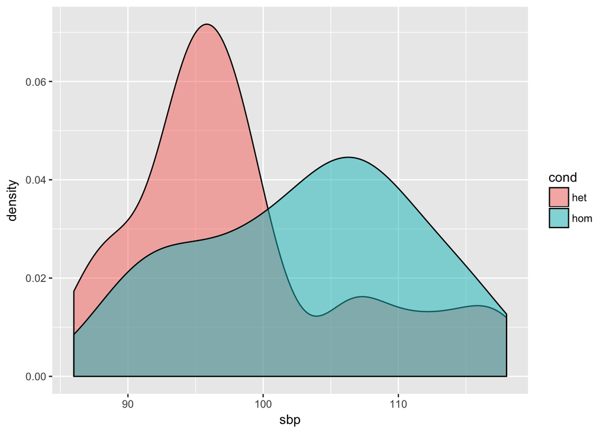

```r
library(ggplot2)
het = c(86, 88, 89, 89, 92, 93, 94, 94, 94,
      95, 95, 96, 96, 97, 97, 98, 98, 99,
      99, 101, 106, 107, 110, 113, 116, 118)
hom = c(89, 90, 92, 93, 93, 96, 99, 99, 99, 102,
  103, 104, 105, 106, 106, 107, 108, 108, 110, 110,
  112, 114, 116, 116)
cond = c(rep("het", length(het)), rep("hom", length(hom)))
dat <- data.frame( cond, sbp=c(het, hom) )
ggplot(dat, aes(x = sbp, fill = cond)) +
   geom_density(alpha = 0.5)
```

### Boxplot of hypertension data

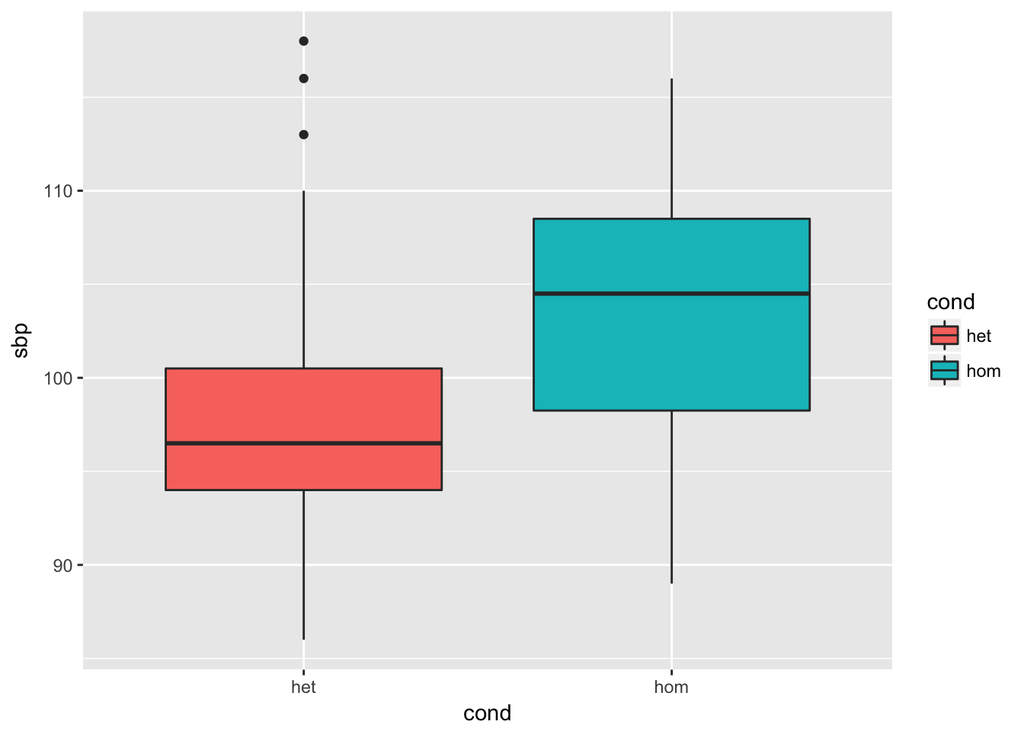

```r
library(ggplot2)
het = c(86, 88, 89, 89, 92, 93, 94, 94, 94,
      95, 95, 96, 96, 97, 97, 98, 98, 99,
      99, 101, 106, 107, 110, 113, 116, 118)
hom = c(89, 90, 92, 93, 93, 96, 99, 99, 99, 102,
  103, 104, 105, 106, 106, 107, 108, 108, 110, 110,
  112, 114, 116, 116)
cond = c(rep("het", length(het)), rep("hom", length(hom)))
dat <- data.frame( cond, sbp=c(het, hom) )
ggplot(dat, aes(x=cond, y=sbp, fill=cond, width=0.3)) +
  geom_boxplot()
```

### R code for permutation test with hypertension data

```r
het = c(86, 88, 89, 89, 92, 93, 94, 94, 94,
        95, 95, 96, 96, 97, 97, 98, 98, 99,
       99, 101, 106, 107, 110, 113, 116, 118)
hom = c(89, 90, 92, 93, 93, 96, 99, 99, 99, 102,
  103, 104, 105, 106, 106, 107, 108, 108, 110, 110,
  112, 114, 116, 116)
set.seed(2017)
diff.obs = mean(hom) - mean(het)
n.perm=5000
diff.perm=rep(NA, n.perm)
len.het=length(het)
len.hom=length(hom)
hethom = c(het, hom)
for (i in 1 : n.perm) {
    het.perm = sample(hethom, len.het, replace=TRUE)
    hom.perm = sample(hethom, len.hom, replace=TRUE)
    diff.perm[i] = mean(hom.perm) - mean(het.perm)
 }
p.perm = sum( abs(diff.perm) >= abs(diff.obs) ) / n.perm
print(p.perm)
```

```
## [1] 0.0454
```

### How to calculate P-value

Recall the definition: the p-value is the probability obtaining a test statistic as extreme as or more extrement than the observed statistic given that the null hypothesis is true.

- In a parametric test (e.g. t-test), one makes assumptions about the parameters of the population distributions from which data are drawn and the p-value is calculated from this distribution function.
- In a non-parametric test (e.g. wilcox test), one makes no assumptions about the parameters of the population and the p-value is calculated based on ranks and probabilities.
- In a permutation test, there is no specific assumption about distributions, so test statistics are generated by permuting the data.

### Statistical test of hypentension data

```r
het = c(86, 88, 89, 89, 92, 93, 94, 94, 94,
      95, 95, 96, 96, 97, 97, 98, 98, 99,
      99, 101, 106, 107, 110, 113, 116, 118)
hom = c(89, 90, 92, 93, 93, 96, 99, 99, 99, 102,
  103, 104, 105, 106, 106, 107, 108, 108, 110, 110,
  112, 114, 116, 116)
t.test(het, hom)$p.value
```

```
## [1] 0.04824252
```

```r
wilcox.test(het, hom, exact=FALSE)$p.value
```

```
## [1] 0.04417628
```

### Statistical power

The power of a statistical test is the probability of correctly rejecting the null hypothesis when it is false and defined as 1 - beta = Pr(reject null hupothesis when it is false)

### Example: Coronary heart disease

- Consider a clinical trial for evaluation of the effect of a test drug on cholesterol in patients with coronary heart disease (CHD).
- Cholesterol is the main lipid associated with atherosclerotic vascular disease (ASVD). The purpose of cholesterol testing is to identify patients at risk for atherosclerosis.
- About 75% of the cholesterol is bound to low density lipoproteins (LDLs) and 25% to high density lipoproteins (HDLs). Of these, LDL is the most directly associate with increased risk of CHD.
- A pharmaceutical company is interested in conducting a clinical trial to compare two cholesterol lowering agents for treatment of patients with CHD through a parallel design. The primary efficacy parameter is the LDL.
- Suppose a difference of 5% in percent change of LDL is considered of clinically meaningful difference.
- Assume that the standard deviation is 10%.
- What is the required sample size per group to achieve an 80% power at the 5% significance level?
- Reference: Chow,S et al. (2008) Sample size calculations in clinical research. Boca Raton,FL. Chapman and Hall/CRC.

### Estimate required sample size in a study

```
## [1] 63
```

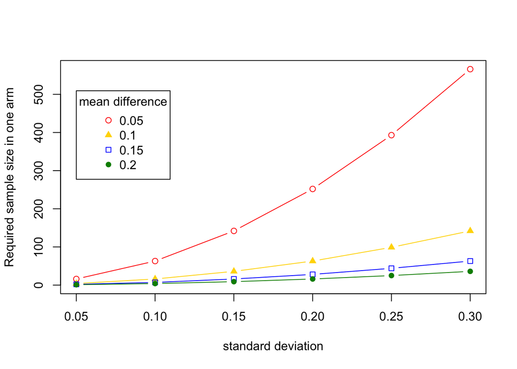

### R code for sample size estimation about t-test

```r
# DEFINE A FUNCTION
ss.two_sample_mean = function(sigma, epsilon, alpha, beta) {
    term.top =  (qnorm(1-alpha/2) + qnorm(beta) )^2 * sigma^2 * 2
    term.bottom <-  abs(epsilon)^2
    return(  ceiling( term.top / term.bottom ) )
}

# RUN A FUNCTION FOR A CORONARY HEART DISEASE EXAMPLE
ss.two_sample_mean(0.1, 0.05, 0.05, 0.8)
# [1] 63

# VARY PARAMETERS
my.sigma = seq(0.05, 0.3, 0.05); my.epsilon = seq(0.05, 0.2, 0.05)
len.sigma = length(my.sigma); len.epsilon = length(my.epsilon);
my.ssize = matrix(1, nrow=len.sigma, ncol=len.epsilon, byrow=TRUE)
for(i in 1:len.sigma) {
   for(j in 1:len.epsilon) {
      my.ssize[i,j] = ss.two_sample_mean(my.sigma[i], my.epsilon[j], 0.05, 0.8)
    }
}

# DRAW A PLOT
my.color = c("red", "gold", "blue", "green4")
plot(my.sigma, my.ssize[,1], type="b", ylim=c(0, max(my.ssize)), col = my.color[1],
      xlab="standard deviation", ylab="Required sample size in one arm" )
points(my.sigma, my.ssize[,2], type="b", pch=17, col=my.color[2] )
points(my.sigma, my.ssize[,3], type="b", pch=22, col=my.color[3] )
points(my.sigma, my.ssize[,4], type="b", pch=16, col=my.color[4] )
legend(my.sigma[1], max(my.ssize)*0.9,  legend=my.epsilon, pch=c(1, 17, 22, 16),
    col = my.color, title="mean difference"  )
```

### pwr, an R package for sample size estimation

```r
library(pwr)
delta <- 0.05
sigma <- 0.1
d <- delta/sigma
pwr.t.test(d = d, sig.level = 0.05, power = 0.8, type = 'two.sample')$n
```

```
## [1] 63.76561
```